# The Research Mindmap

[figure not shown]

[interactive chart not shown]

# Overview

The following flowchart illustrates the research workflow, detailing the key methodologies and how they are interconnected. It starts from the problem identification and moves through volatility modeling, predictive modeling, and optimization processes.

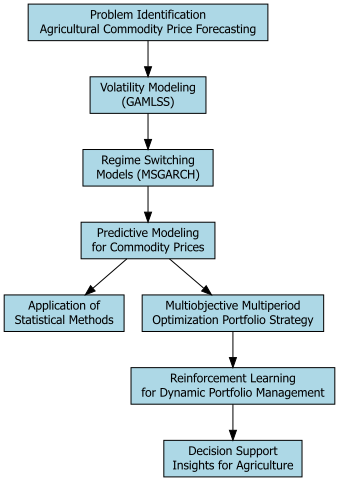

# Research Proposal: Advanced Techniques for Multiperiod Multiobjective Portfolio Optimization in Commodity Markets

This research addresses the significant challenge of **modeling and forecasting agricultural commodity prices**, which are subject to high volatility and complex dynamics. Agricultural markets are highly sensitive to external factors such as **climatic changes, geopolitical events, and supply-demand imbalances**, making accurate forecasting and risk management difficult for investors and policymakers.

### Key Components of the Research:

1. **Volatility Modeling Using GAMLSS and MSGARCH**:
   - **GAMLSS**: This technique provides a nuanced understanding of the **distributional characteristics** of commodity returns, capturing the probabilistic behaviors that traditional models often overlook.
   - **MSGARCH**: By implementing the **Markov-Switching GARCH** model, the research captures **regime shifts in volatility**, which are common in commodities due to external shocks and systemic changes.
2. **Multi-Objective Portfolio Optimization**:
   - This step involves developing a **multi-objective optimization framework** using evolutionary algorithms such as **NSGA-II** and **Differential Evolution (DEOptim)**. These algorithms help optimize portfolio allocation by balancing risk, return, and diversification, particularly for portfolios with high-volatility assets like agricultural commodities.
3. **Reinforcement Learning for Portfolio Management**:
   - The research also introduces **Reinforcement Learning (RL)** methods, such as **Q-Learning** and **K-Bandit algorithms**, to adaptively manage portfolio strategies. These techniques are particularly suited for **dynamic portfolio management**, allowing strategies to evolve as market conditions change.

### Contribution to Knowledge:

The research’s **innovative contribution** lies in combining these advanced econometric and machine learning techniques to tackle the unique challenges of commodity markets. It offers a **comprehensive methodological framework** that improves the modeling and forecasting of volatility and returns in agricultural commodities. This work enhances **portfolio optimization strategies**, offering practical applications for financial markets by providing tools that help portfolio managers make informed, data-driven decisions in the face of volatile market conditions.

**Final Objective**: The primary goal of this research is to develop **robust methods for volatility modeling** and **portfolio optimization** that dynamically adapt to market conditions. This approach offers a significant advancement in both academic and professional fields by providing actionable insights for managing portfolios in volatile commodity markets.

Here we can see an much more complete and [interactive mindmap: (if the HTML doesn´t work, see the pic below)](https://whimsical.com/thesis-proposal-4KahXwYqBXLwQHDBvjPK5j)

[figure not shown]

Another mindmap tryed to be made with networkD3

```r
# Libraries
library(networkD3)
library(dplyr)

# Create the dataset (edges) for the mind map
data <- data.frame(
  from = c(
    # Edges from the root node
    "PhD Thesis Proposal", "PhD Thesis Proposal", "PhD Thesis Proposal",
    "PhD Thesis Proposal", "PhD Thesis Proposal", "PhD Thesis Proposal", "PhD Thesis Proposal",

    # Edges under "Research Motivation"
    "Research Motivation", "Research Motivation",

    # Edges under "Methodological Framework"
    "Methodological Framework", "Methodological Framework",

    # Edges under "Econometric Modeling Techniques & Volatility Modeling Approaches"
    "Econometric Modeling Techniques & Volatility Modeling Approaches", "Econometric Modeling Techniques & Volatility Modeling Approaches",

    # Edges under "Portfolio Optimization & Allocation"
    "Portfolio Optimization & Allocation", "Portfolio Optimization & Allocation",

    # Edges under "Multi-Objective Portfolio Optimization Framework"
    "Multi-Objective Portfolio Optimization Framework", "Multi-Objective Portfolio Optimization Framework",

    # Edges under "Optimization Algorithms"
    "Optimization Algorithms", "Optimization Algorithms",

    # Edges under "Expected Contributions"
    "Expected Contributions", "Expected Contributions",

    # Edges under "Work Plan & Timeline"
    "Work Plan & Timeline", "Work Plan & Timeline", "Work Plan & Timeline",
    "Work Plan & Timeline", "Work Plan & Timeline", "Work Plan & Timeline"
  ),
  to = c(
    # Children of "PhD Thesis Proposal"
    "Research Motivation", "Methodological Framework", "Dynamic Programming for Multi-Period Optimization",
    "Empirical Validation", "Practical Guidelines", "Expected Contributions", "Work Plan & Timeline",

    # Children of "Research Motivation"
    "Challenges in Commodity Markets", "Need for Improved Forecasting & Risk Management",

    # Children of "Methodological Framework"
    "Econometric Modeling Techniques & Volatility Modeling Approaches", "Portfolio Optimization & Allocation",

    # Children of "Econometric Modeling Techniques & Volatility Modeling Approaches"
    "Distributional Analysis (GAMLSS Framework)", "Volatility & Regime Switching (MSGARCH Models)",

    # Children of "Portfolio Optimization & Allocation"
    "Reinforcement Learning for Allocation (K-Bandit & Q-Learning)", "Multi-Objective Portfolio Optimization Framework",

    # Children of "Multi-Objective Portfolio Optimization Framework"
    "Objective Functions (Return, Risk, Entropy)", "Optimization Algorithms",

    # Children of "Optimization Algorithms"
    "Differential Evolution (DE)", "NSGA-II",

    # Children of "Expected Contributions"
    "Advances in Volatility Modeling", "Innovative Portfolio Optimization",

    # Children of "Work Plan & Timeline"
    "1-3 Months: Data Collection", "4-6 Months: Develop GAMLSS & MSGARCH",
    "7-9 Months: Model Comparison & Optimization Framework", "10-12 Months: Integrate Reinforcement Learning",
    "13-15 Months: Empirical Validation", "16-18 Months: Final Analysis & Thesis"
  ),
  stringsAsFactors = FALSE
)

# Plot the network using simpleNetwork from networkD3
simpleNetwork(data,
              height = "800px",
              width = "100%",
              Source = 1,      # column number for source nodes
              Target = 2,      # column number for target nodes
              linkDistance = 100,  # adjust as needed for spacing
              charge = -300,       # node repulsion (tweak for layout)
              fontSize = 14,       # font size for node labels
              fontFamily = "serif",
              linkColour = "#666", # color of the links
              nodeColour = "#69b3a2",  # color of the nodes
              opacity = 0.9,       # overall opacity
              zoom = TRUE          # allow zooming
)
```

[interactive chart not shown]